# human SI transcriptomics

A. Gabor

8/19/2020

The following script shows the problem with differential expression analysis and a potential fix to it.

Number of genes are the same between conditions:

```
## # A tibble: 9 x 2
##   fileID     n_genes
##   <chr>        <int>
## 1 1000uM_24h   16548
## 2 1000uM_48h   16548
## 3 1000uM_72h   16548
## 4 100uM_24h    16548
## 5 100uM_48h    16548
## 6 100uM_72h    16548
## 7 10uM_24h     16548
## 8 10uM_48h     16548
## 9 10uM_72h     16548
```

Checking the distribution of the log2FC data:

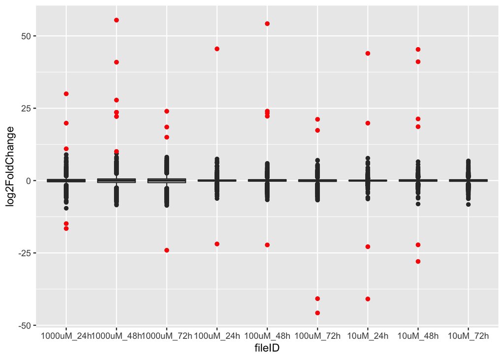

There are some extreme values log2FC >50, which is probably a division by 0 problem, since 2^50 ~ 1e15. We have emailed Daniela and Terezinha about this problem.

Genes with log2Fc larger than 10 are:

```
## # A tibble: 37 x 10
##    fileID concentration  time ensembl_gene_id baseMean log2FoldChange lfcSE
##    <chr>          <dbl> <dbl> <chr>              <dbl>          <dbl> <dbl>
##  1 1000u…          1000    24 ENSG00000275719    21.4            30.0  3.77
##  2 1000u…          1000    24 ENSG00000213442   759.            -14.9  3.28
##  3 1000u…          1000    24 ENSG00000202198    13.5           -16.6  8.24
##  4 1000u…          1000    24 ENSG00000279033     5.86           11.0  8.33
##  5 1000u…          1000    24 ENSG00000260934     7.72           19.8  8.25
##  6 1000u…          1000    48 ENSG00000213442   759.             55.5  3.25
##  7 1000u…          1000    48 ENSG00000272540    11.6            23.6  2.41
##  8 1000u…          1000    48 ENSG00000160683    52.4            23.6  3.09
##  9 1000u…          1000    48 ENSG00000274226    17.2            27.8  5.12
## 10 1000u…          1000    48 ENSG00000202198    13.5            40.9  8.25
## # … with 27 more rows, and 3 more variables: stat <dbl>, pvalue <dbl>,
## #   padj <dbl>
```

Principal components analysis:

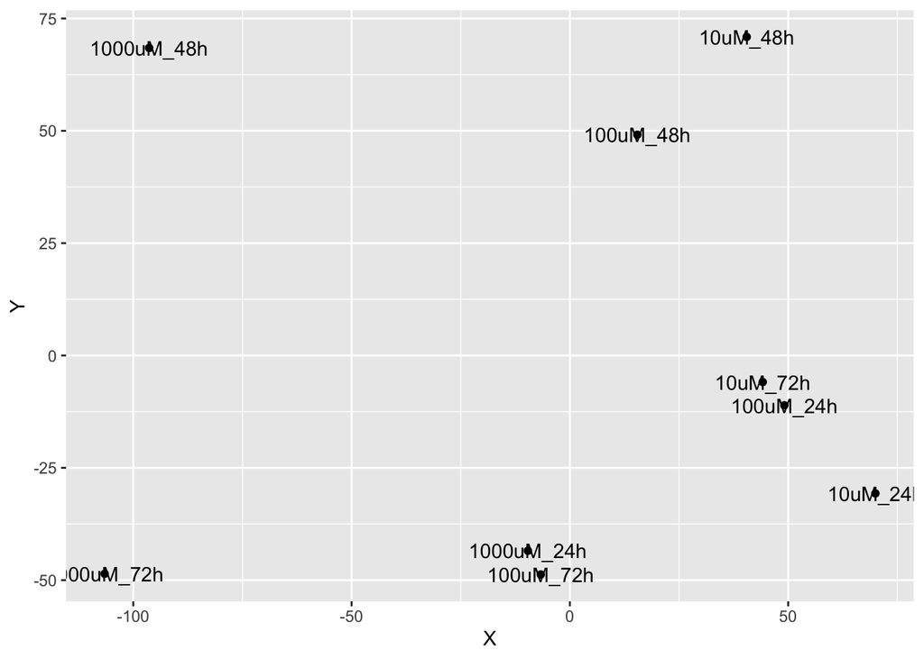

The PCA is also a bit strange: why the 48h samples are clustering away from the other 2 time-points?

### Gene filtering

We traced back a gene with large fold change and it has 0 counts in all the three replica. This indicates that the preprocessing pipeline cannot handle genes with zero expression.

We don’t have access to the pipeline, so here we filter out genes that have zero counts in 2 out of the 3 replica in any condition (in the raw data).

How many genes we loose if we remove those who are not expressed in a condition? In the table: TRUE: remove; FALSE: keep.

```r
# which genes to remove:
# the ones that have n_positive <2 in at least 1 condition:
raw_count_stats <- raw_count_stats %>%
    group_by(gene_ensembl_id) %>%
    summarise(to_remove = any(n_positive < 2))
raw_count_stats %>%
    pull(to_remove) %>% table() %>% print()
```

```
## .
## FALSE  TRUE
## 16552 41843
```

```r
keep_genes <- raw_count_stats %>% filter(!to_remove) %>% pull(gene_ensembl_id)
```

we would remove 41.8k genes and keep 16552.

```r
filtered_transcript_data <- transcript_data %>% filter(ensembl_gene_id %in% keep_genes)
```

Now the boxplot looks much nicer:

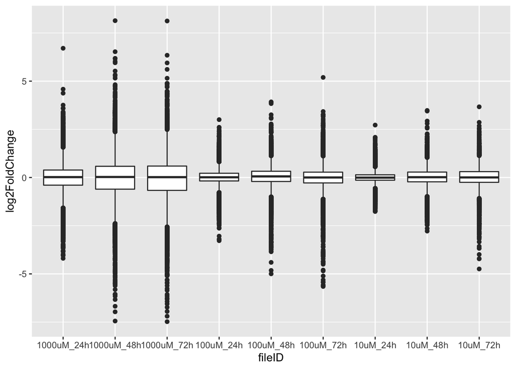

Checking pca:

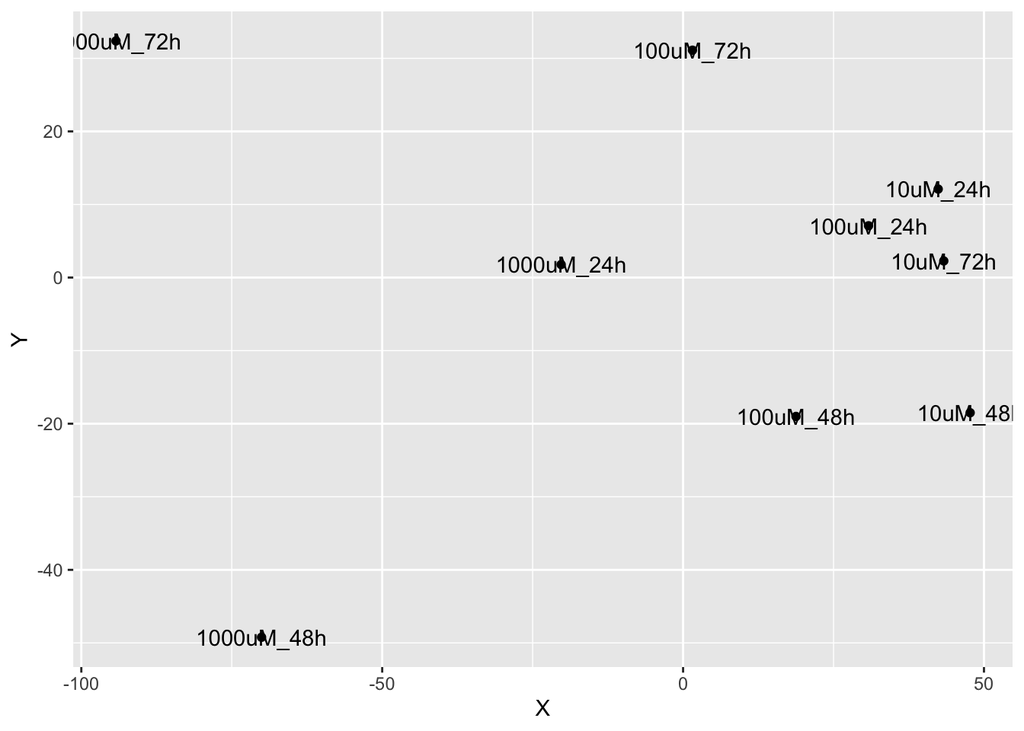

The 48h data are still further away, but the points are spread more homogenously.